# PSI_Assignment 1: Digital Portfolio: Analyse Part

Na Li (D19125334)

```r
knitr::opts_chunk$set(echo = TRUE)
needed_packages <- c("VIM", "tidyverse","pastecs", "ggplot2", "semTools", "psych", "FSA", "car", "effectsize", "coin", "rstatix", "sjstats", "userfriendlyscience", "stats", "foreign", "gmodels", "lm.beta","stargazer", "lmtest", "DescTools", "nnet", "reshape2", "generalhoslem", "Epi", "arm", "regclass", "olsrr")
# Extract not installed packages
not_installed <- needed_packages[!(needed_packages %in% installed.packages()[, "Package"])]
# Install not installed packages
if(length(not_installed)) install.packages(not_installed)

library(pastecs) #For creating descriptive statistic summaries
library(ggplot2) #For creating histograms with more detail than plot
library(semTools) #For skewness and kurtosis
library(psych)  #For descriptive functions
library(FSA) #For percentage
library(car) # For Levene's test for homogeneity of variance and  test for colinearity of predictors
library(effectsize) #To calculate effect size for t-test
library(VIM)
library(tidyverse)
library(coin) # For Wilcox test (non-parametric)
library(rstatix) # For calculating effect size
library(sjstats) #calculate effect size for t-test
library(userfriendlyscience)
library(stats)
library(foreign) # open SPSS file, I may not use that.
library(gmodels) #For creating histograms with more detail than plot
library(stargazer)#For formatting outputs/tables for regression
library(lm.beta) # to isolate the beta co-efficients for regression

#Multinomial regression
library(lmtest)
library(DescTools)
library(nnet) #Multinomial regression
library(reshape2)
library(generalhoslem) #For test of fit for logistic regression, test assumption of linearity
library(Epi) #ROC Curve
library(arm) #for invlogit calculating predicted probabilities
library(regclass) #For confusion matrix
library(olsrr)
getwd()
```

```
## [1] "/home/d19125334/Documents/PhD_Modules_2021/ProbilityandStatisiticInference/assignment/assignment1/Assignment1"
```

```r
stdMathData=read.table("student-mat.csv",sep=";",header=TRUE) #read student
stdPorlagData=read.table("student-por.csv",sep=";",header=TRUE)


stdMergeData=merge(stdMathData,stdPorlagData,by=c("school","sex","age","address","famsize","Pstatus","Medu","Fedu","Mjob","Fjob","reason","nursery","internet"))

colnames(stdMathData) <- tolower(colnames(stdMathData))
colnames(stdPorlagData) <- tolower(colnames(stdPorlagData))
colnames(stdMergeData) <- tolower(colnames(stdMergeData))
```

# Analyse

## Difference for parametric/non-parametric

### Parametric test (independent t-test/levene’s test)

1. absences – by internet

```r
# the variable: the number of absences has generated histogram and summary statistics in th "Explore Data"
# describle the number of absences by internet group
# internet: Internet access at home (binary: yes or no)

# number of absences has been generated histogram and summary statistics in th "Explore Data"
# get descriptive statistics by internet group
psych::describeBy(stdMathData$absences, stdMathData$internet, mat=TRUE)
```

```
##     item group1 vars   n     mean       sd median  trimmed    mad min max range
## X11    1     no    1  66 3.893939 4.253971      2 3.203704 2.9652   0  18    18
## X12    2    yes    1 329 6.072948 8.517960      4 4.501887 5.9304   0  75    75
##         skew  kurtosis        se
## X11 1.344161  1.353925 0.5236276
## X12 3.500338 19.092260 0.4696103
```

```r
# Levene's test for homogenity of variable
car::leveneTest(absences ~ internet, data=stdMathData)
```

```
## Levene's Test for Homogeneity of Variance (center = median)
##        Df F value  Pr(>F)
## group   1  4.8937 0.02753 *
##       393
## ---
## Signif. codes:  0 '***' 0.001 '**' 0.01 '*' 0.05 '.' 0.1 ' ' 1
```

```r
# Conduct the t-test
# var.equal = True is to specify equal variances and a pooled variance estimate.
res <- stats::t.test(absences ~ internet, var.equal=TRUE, data=stdMathData)
res
```

```
##
##  Two Sample t-test
##
## data:  absences by internet
## t = -2.0266, df = 393, p-value = 0.04337
## alternative hypothesis: true difference in means is not equal to 0
## 95 percent confidence interval:
##  -4.2928311 -0.0651868
## sample estimates:
##  mean in group no mean in group yes
##          3.893939          6.072948
```

```r
# statistically significant difference was found
#Cohen's d
# Reporting guideline: Cohen’s d
#0.2=small effect, 0.5=moderate, 0.8 = large

effsize = round((2 * res$statistic)/sqrt(res$parameter), 2)

#using function from effectize package
effectsize::t_to_d(t=res$statistic, res$parameter)
```

```
##     d |         95% CI
## ----------------------
## -0.20 | [-0.40, -0.01]
```

```r
# statistically significant difference was found
# Eta
# reporting guideline: on effect size: 0.01 = small, 0.06 = moderate, 0.14 =large
effes=round((res$statistic*res$statistic)/((res$statistic*res$statistic)+(res$parameter)),3)

effes
```

```
##    t
## 0.01
```

Report this t-test result:

```
1. Reporting the results with Cohen’s d effect
An independent-samples t-test was conducted to compare the number of absences of Math course for students who have internet at home and those who do not have internet at home. There is a slight Significant difference in the scores for absences was found (M=6.07, SD=8.52 for students who have internet at home, M=3.89, SD=4.25 for students who do not have internet at home), t(393)= -2.027, p-value = 0.043). Cohen's d also indicated a small effect size (-0.20).

2. Reporting the results with eta squared effect
An independent-samples t-test was conducted to compare the number of absences of Math course for students who have internet at home and those who do not have internet at home. There is a slight Significant difference in the scores for absences was found (M=6.07, SD=8.52 for students who have internet at home, M=3.89, SD=4.25 for students who do not have internet at home), t(393)= -2.027, p-value = 0.043). A small effect size was also indicated by the eta squared value (0.01).
```

2. g3 — by paid (extra paid classes within the course subject(math) (yes/no)

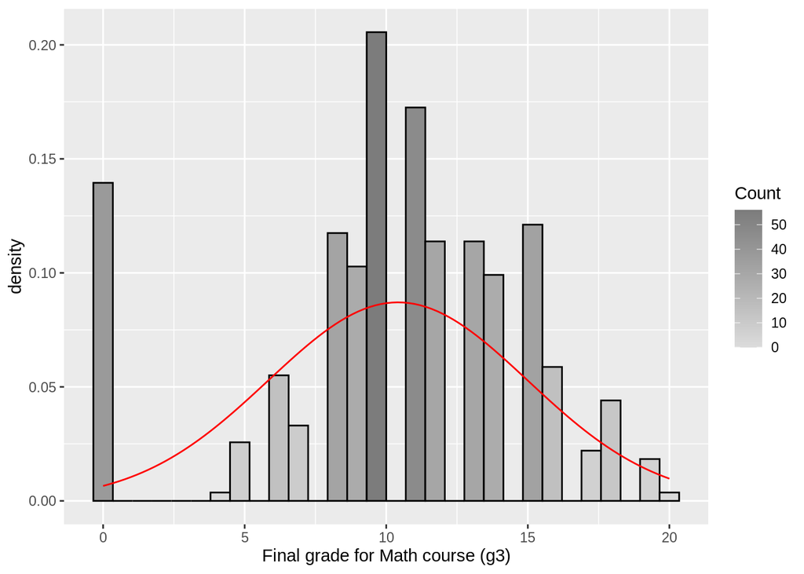

```r
# g3 should be generaged histogram and summary statistics
ggplot(stdMathData, aes(x=g3))+
       labs(x="Final grade for Math course (g3)") +
       geom_histogram(bins=30, colour="black", aes(y=..density.., fill=..count..)) +             scale_fill_gradient("Count", low="#DCDCDC", high="#7C7C7C") +
       stat_function(fun=dnorm, color="red",args=list(mean=mean(stdMathData$g3, na.rm=TRUE), sd=sd(stdMathData$g3, na.rm=TRUE)))
```

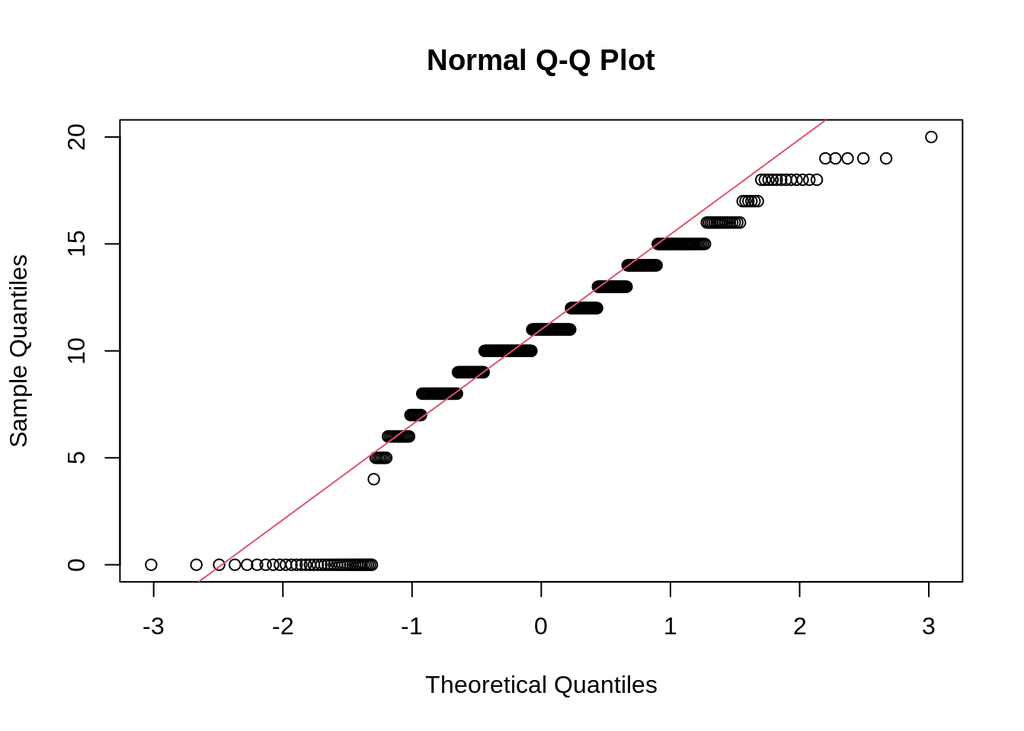

```r
# Q-Q plot
qqnorm(stdMathData$g3)
qqline(stdMathData$g3, col=2)
```

```r
#g3 generae summary statistics
pastecs::stat.desc(stdMathData$g3, basic=F)
```

```
##       median         mean      SE.mean CI.mean.0.95          var      std.dev
##   11.0000000   10.4151899    0.2305174    0.4531979   20.9896164    4.5814426
##     coef.var
##    0.4398809
```

```r
#skewness and kurtosis
tpskew <- semTools::skew(stdMathData$g3)
tpkurt <- semTools::kurtosis(stdMathData$g3)

tpskew
```

```
##     skew (g1)            se             z             p
## -7.326724e-01  1.232472e-01 -5.944738e+00  2.768992e-09
```

```r
tpkurt
```

```
## Excess Kur (g2)              se               z               p
##       0.4034208       0.2464944       1.6366327       0.1017072
```

```r
tpskew[1]/tpskew[2]
```

```
## skew (g1)
## -5.944738
```

```r
tpkurt[1]/tpkurt[2]
```

```
## Excess Kur (g2)
##        1.636633
```

```r
mathg3<- abs(scale(stdMathData$g3))
FSA::perc(as.numeric(mathg3), 1.96, "gt")
```

```
## [1] 9.873418
```

```r
FSA::perc(as.numeric(mathg3), 3.29, "gt")
```

```
## [1] 0
```

```r
# get descriptive statistics by paid group
psych::describeBy(stdMathData$g3, stdMathData$paid, mat=TRUE)
```

```
##     item group1 vars   n      mean       sd median  trimmed    mad min max
## X11    1     no    1 214  9.985981 5.126090     11 10.29651 4.4478   0  20
## X12    2    yes    1 181 10.922652 3.791011     11 11.15862 2.9652   0  19
##     range       skew   kurtosis        se
## X11    20 -0.6072329 -0.2873359 0.3504123
## X12    19 -0.6949883  1.2425098 0.2817836
```

```r
# Levene's test for homogenity of variable
car::leveneTest(g3 ~ paid, data=stdMathData)
```

```
## Levene's Test for Homogeneity of Variance (center = median)
##        Df F value  Pr(>F)
## group   1  13.123 0.00033 ***
##       393
## ---
## Signif. codes:  0 '***' 0.001 '**' 0.01 '*' 0.05 '.' 0.1 ' ' 1
```

```r
# Conduct the t-test
# var.equal = True is to specify equal variabnces and a pooled variance extimate.
res_g3 <- stats::t.test(g3 ~ paid, var.equal=TRUE, data=stdMathData)
res_g3
```

```
##
##  Two Sample t-test
##
## data:  g3 by paid
## t = -2.0326, df = 393, p-value = 0.04277
## alternative hypothesis: true difference in means is not equal to 0
## 95 percent confidence interval:
##  -1.84266024 -0.03068101
## sample estimates:
##  mean in group no mean in group yes
##          9.985981         10.922652
```

```r
# statistically significant difference was found
#Cohen's d
# Reporting guideline: Cohen’s d
#0.2=small effect, 0.5=moderate, 0.8 = large

effsize = round((2 * res_g3$statistic)/sqrt(res_g3$parameter), 2)

#using function from effectize package
effectsize::t_to_d(t=res_g3$statistic, res_g3$parameter)
```

```
##     d |         95% CI
## ----------------------
## -0.21 | [-0.40, -0.01]
```

```r
# statistically significant difference was found
# Eta
# reporting guideline: on effect size: 0.01 = small, 0.06 = moderate, 0.14 =large
effes=round((res_g3$statistic*res_g3$statistic)/((res_g3$statistic*res_g3$statistic)+(res_g3$parameter)),3)

effes
```

```
##    t
## 0.01
```

Report this t-test result:

```
1. Reporting the results with Cohen’s d effect
An independent-samples t-test was conducted to compare the final grade (g3) for students who have extra paid classes within the course math subject and those who do not have extra paid classes within the course math subject. There is a slight Significant difference in the scores for the third period grade was found (M=10.92, SD=3.79 for students who have extra paid classes, M=10.00, SD=5.13 for students who do not have extra paid classes), t(393)= -2.03, p-value < 0.05). Cohen's d also indicated a small effect size (-0.21).

2. Reporting the results with eta squared effect
An independent-samples t-test was conducted to compare the final grade (g3) for students who have extra paid classes within the course math subject and those who do not have extra paid classes within the course math subject. There is a slight Significant difference in the scores for the third period grade was found (M=10.92, SD=3.79 for students who have extra paid classes, M=10.00, SD=5.13 for students who do not have extra paid classes), t(393)= -2.03, p-value < 0.05). A small effect size was also indicated by the eta squared value (0.01).
```

### Non-Parametric test (Mann-Whitney test)

1. Weekly study time (numeric: 1 - <2 hours, 2 - 2 to 5 hours, 3 - 5 to 10 hours, or 4 - >10 hours)

```r
# get descriptive statistics by sex group
by(stdMathData$studytime, stdMathData$sex, median)
```

```
## stdMathData$sex: F
## [1] 2
## ------------------------------------------------------------
## stdMathData$sex: M
## [1] 2
```

```r
by(stdMathData$studytime, stdMathData$sex, IQR)
```

```
## stdMathData$sex: F
## [1] 1
## ------------------------------------------------------------
## stdMathData$sex: M
## [1] 1
```

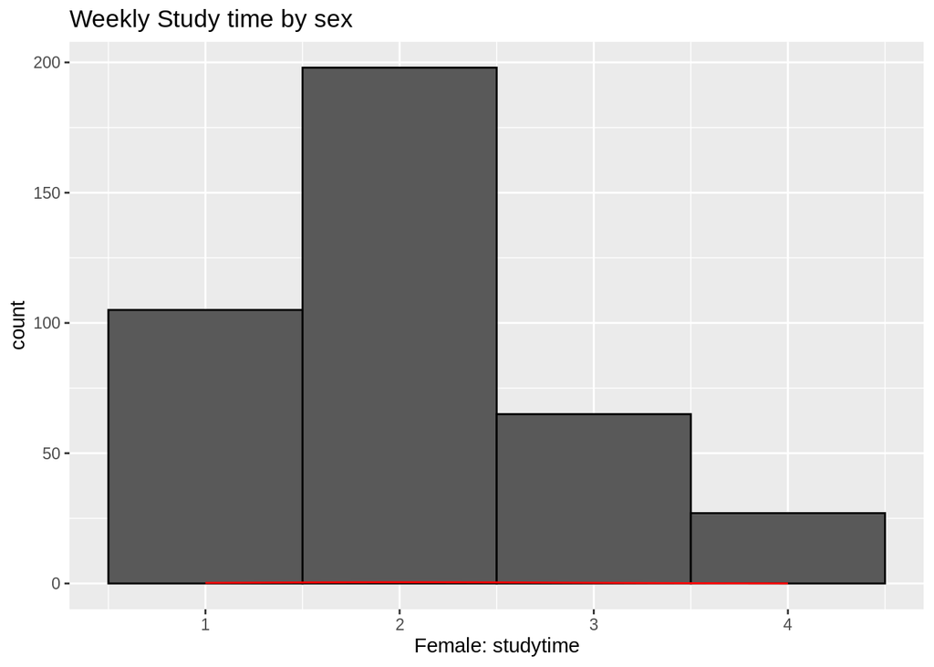

```r
#split dataset by sex
stdMath_F <- subset(stdMathData, sex="F")
stdMath_M <- subset(stdMathData, set="M")

ggplot(stdMath_F, aes(x=studytime)) +
      ggtitle ("Weekly Study time by sex")+
      labs(x="Female: studytime") +
      geom_histogram(bins=4, colour="black") +
      scale_fill_gradient("Count", low="#DCDCDC", high="#7C7C7C") +
      stat_function(fun=dnorm, color="red",args=list(mean=mean(stdMath_F$studytime,                                                       na.rm=TRUE),sd=sd(stdMath_F$studytime, na.rm=TRUE)))
```

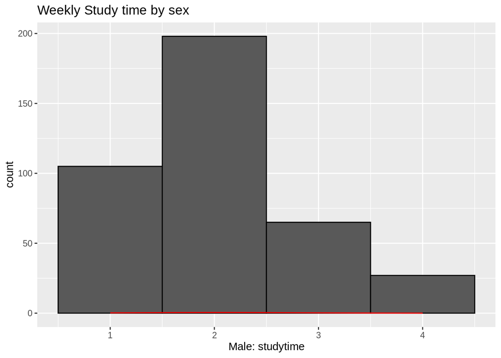

```r
ggplot(stdMath_M, aes(x=studytime)) +
      ggtitle ("Weekly Study time by sex")+
      labs(x="Male: studytime") +
      geom_histogram(bins=4, colour="black") +
      scale_fill_gradient("Count", low="#DCDCDC", high="#7C7C7C") +
      stat_function(fun=dnorm, color="red",args=list(mean=mean(stdMath_M$studytime,                                                       na.rm=TRUE),sd=sd(stdMath_M$studytime, na.rm=TRUE)))
```

```r
#test for differences on Gender to get U statistic
stats::wilcox.test(studytime ~ sex, data = stdMathData)
```

```
##
##  Wilcoxon rank sum test with continuity correction
##
## data:  studytime by sex
## W = 26434, p-value = 2.304e-11
## alternative hypothesis: true location shift is not equal to 0
```

```r
# calculate z-score
coin::wilcox_test(studytime~as.factor(sex), data=stdMathData)
```

```
##
##  Asymptotic Wilcoxon-Mann-Whitney Test
##
## data:  studytime by as.factor(sex) (F, M)
## Z = 6.6858, p-value = 2.297e-11
## alternative hypothesis: true mu is not equal to 0
```

```r
#effect size
wilcoeffsize = rstatix::wilcox_effsize(studytime ~ sex, data=stdMathData)
wilcoeffsize
```

```
## # A tibble: 1 x 7
##   .y.       group1 group2 effsize    n1    n2 magnitude
## * <chr>     <chr>  <chr>    <dbl> <int> <int> <ord>
## 1 studytime F      M        0.336   208   187 moderate
```

```
Reporting the results for the Mann-Whitney test
The weekly study time by female stdMath_F (Mdn=2.00, IQR=1.00) was significantly more study time than male stdMath_M (Mdn=2.00, IQR=1.00), (U=26434.00, z=6.69, p<.001, r=0.34) for Math course sample.
```

2. Current health status ((numeric: from 1 - very bad to 5 - very good)) by extra-curricular activities (yes/no)

```r
# get descriptive statistics by extra-curricular activities
by(stdMathData$health, stdMathData$activities, median)
```

```
## stdMathData$activities: no
## [1] 4
## ------------------------------------------------------------
## stdMathData$activities: yes
## [1] 4
```

```r
by(stdMathData$health, stdMathData$activities, IQR)
```

```
## stdMathData$activities: no
## [1] 2
## ------------------------------------------------------------
## stdMathData$activities: yes
## [1] 2
```

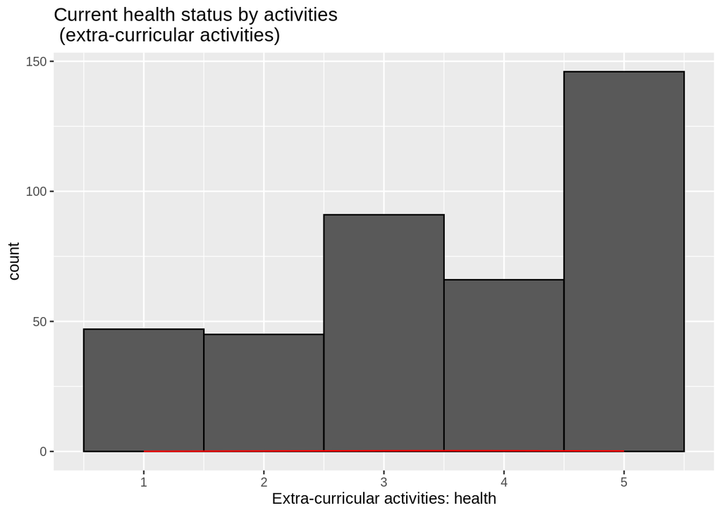

```r
#split dataset by activities
stdMathHealAct_N <- subset(stdMathData, activities="no")
stdMathHealAct_Y <- subset(stdMathData, activities="yes")

ggplot(stdMathHealAct_Y, aes(x=health)) +
      ggtitle ("Current health status by activities \n (extra-curricular activities)")+
      labs(x="Extra-curricular activities: health") +
      geom_histogram(bins=5, colour="black") +
      scale_fill_gradient("Count", low="#DCDCDC", high="#7C7C7C") +
      stat_function(fun=dnorm, color="red",args=list(mean=mean(stdMathHealAct_Y$health,                                                       na.rm=TRUE),sd=sd(stdMathHealAct_Y$health, na.rm=TRUE)))
```

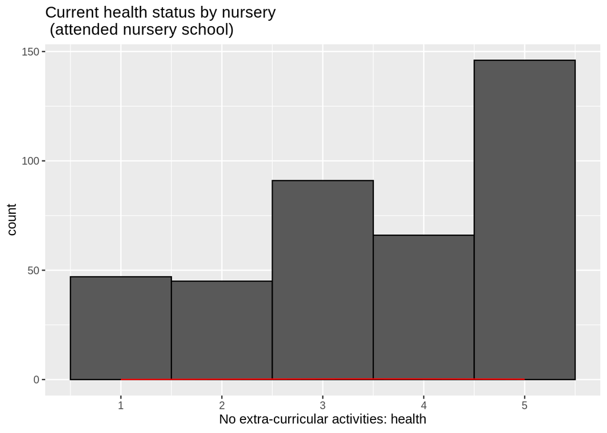

```r
ggplot(stdMathHealAct_N, aes(x=health)) +
      ggtitle("Current health status by nursery \n (attended nursery school)") +
      labs(x="No extra-curricular activities: health") +
      geom_histogram(bins=5, colour="black") +
      scale_fill_gradient("Count", low="#DCDCDC", high="#7C7C7C") +
      stat_function(fun=dnorm, color="red",args=list(mean=mean(stdMathHealAct_N$health,                                                       na.rm=TRUE),sd=sd(stdMathHealAct_N$health, na.rm=TRUE)))
```

```r
#test for differences on Gender to get U statistic: Mann Whitney U (Wilcoxon Test)
stats::wilcox.test(health ~ activities, data = stdMathData)
```

```
##
##  Wilcoxon rank sum test with continuity correction
##
## data:  health by activities
## W = 18882, p-value = 0.5742
## alternative hypothesis: true location shift is not equal to 0
```

```r
# calculate z-score
coin::wilcox_test(health~as.factor(activities), data=stdMathData)
```

```
##
##  Asymptotic Wilcoxon-Mann-Whitney Test
##
## data:  health by as.factor(activities) (no, yes)
## Z = -0.56235, p-value = 0.5739
## alternative hypothesis: true mu is not equal to 0
```

```r
#effect size
wilcoeffsize = rstatix::wilcox_effsize(health ~ activities, data=stdMathData)
wilcoeffsize
```

```
## # A tibble: 1 x 7
##   .y.    group1 group2 effsize    n1    n2 magnitude
## * <chr>  <chr>  <chr>    <dbl> <int> <int> <ord>
## 1 health no     yes     0.0283   194   201 small
```

```
Reporting the results for the Mann-Whitney test
The current health status for students who do not have extra-curricular activities stdMathHealAct_N (Mdn=4.00, IQR=2.00) did not differ significantly from those who have extra-curricular activities stdMathHealAct_Y (Mdn=4.00, IQR=2.00), (U=18882.00, z=-0.56, p=0.57, r=0.028).
```

## Repeat measure for difference

### Parametric test (paired t-test)

G1 and G2 and g3 repeat measure

```r
pastecs::stat.desc(stdMathData$g1, basic=F)
```

```
##       median         mean      SE.mean CI.mean.0.95          var      std.dev
##   11.0000000   10.9088608    0.1670068    0.3283359   11.0170533    3.3191947
##     coef.var
##    0.3042659
```

```r
pastecs::stat.desc(stdMathData$g2, basic=F)
```

```
##       median         mean      SE.mean CI.mean.0.95          var      std.dev
##   11.0000000   10.7139241    0.1892618    0.3720894   14.1489173    3.7615047
##     coef.var
##    0.3510856
```

```r
# paired t-test g1-g2
res_g12 <- t.test(stdMathData$g1, stdMathData$g2, paired=TRUE)
res_g12
```

```
##
##  Paired t-test
##
## data:  stdMathData$g1 and stdMathData$g2
## t = 1.9648, df = 394, p-value = 0.05014
## alternative hypothesis: true difference in means is not equal to 0
## 95 percent confidence interval:
##  -0.0001220737  0.3899954914
## sample estimates:
## mean of the differences
##               0.1949367
```

```r
# statistically significant difference was found
# Eta
# reporting guideline: on effect size: .01 = small, .06 = moderate, .14 =large
effes=round((res_g12$statistic*res_g12$statistic)/((res_g12$statistic*res_g12$statistic)+(res_g12$parameter)),3)

effes
```

```
##    t
## 0.01
```

[output not shown]

```r
pastecs::stat.desc(stdMathData$g2, basic=F)
```

```
##       median         mean      SE.mean CI.mean.0.95          var      std.dev
##   11.0000000   10.7139241    0.1892618    0.3720894   14.1489173    3.7615047
##     coef.var
##    0.3510856
```

```r
pastecs::stat.desc(stdMathData$g3, basic=F)
```

```
##       median         mean      SE.mean CI.mean.0.95          var      std.dev
##   11.0000000   10.4151899    0.2305174    0.4531979   20.9896164    4.5814426
##     coef.var
##    0.4398809
```

```r
# paired t-test g1-g2
res_g23 <- t.test(stdMathData$g2, stdMathData$g3, paired=TRUE)
res_g23
```

```
##
##  Paired t-test
##
## data:  stdMathData$g2 and stdMathData$g3
## t = 2.9869, df = 394, p-value = 0.002994
## alternative hypothesis: true difference in means is not equal to 0
## 95 percent confidence interval:
##  0.1021055 0.4953629
## sample estimates:
## mean of the differences
##               0.2987342
```

```r
# statistically significant difference was found
# Eta
# reporting guideline: on effect size: .01 = small, .06 = moderate, .14 =large
effes=round((res_g23$statistic*res_g23$statistic)/((res_g23$statistic*res_g23$statistic)+(res_g23$parameter)),3)

effes
```

```
##     t
## 0.022
```

[output not shown]

### Non-Parametric test — sample for Math course

```r
# dalc and walc by sex repeat measure
# get subset data by sex
variableint <- c("sex", "dalc", "walc")
stdMath_F <- subset(stdMathData, sex=="F")[variableint]
stdMath_M <- subset(stdMathData, sex=="M")[variableint]

# wilcoxon test should both sub samples are the same length
# randomly choose the data in the female sub-samples
#set.seed(2000)
#stdMath_F <- sample_n(stdMath_F, nrow(stdMath_M))

summary(stdMath_F)
```

```
##      sex                 dalc            walc
##  Length:208         Min.   :1.000   Min.   :1.000
##  Class :character   1st Qu.:1.000   1st Qu.:1.000
##  Mode  :character   Median :1.000   Median :2.000
##                     Mean   :1.255   Mean   :1.957
##                     3rd Qu.:1.000   3rd Qu.:3.000
##                     Max.   :5.000   Max.   :5.000
```

```r
summary(stdMath_M)
```

```
##      sex                 dalc            walc
##  Length:187         Min.   :1.000   Min.   :1.000
##  Class :character   1st Qu.:1.000   1st Qu.:1.000
##  Mode  :character   Median :1.000   Median :3.000
##                     Mean   :1.733   Mean   :2.663
##                     3rd Qu.:2.000   3rd Qu.:4.000
##                     Max.   :5.000   Max.   :5.000
```

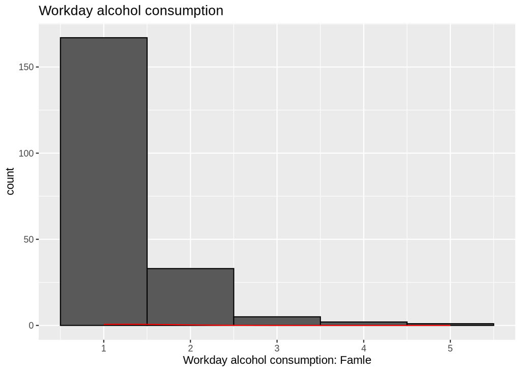

```r
# checking if the statistics dalc and walc are non parametric
# Workday alcohol consumption
ggplot(stdMath_F, aes(x=dalc)) +
      ggtitle ("Workday alcohol consumption")+
      labs(x="Workday alcohol consumption: Famle") +
      geom_histogram(bins=5, colour="black") +
      scale_fill_gradient("Count", low="#DCDCDC", high="#7C7C7C") +
      stat_function(fun=dnorm, color="red",args=list(mean=mean(stdMath_F$dalc,                                                       na.rm=TRUE),sd=sd(stdMath_F$dalc, na.rm=TRUE)))
```

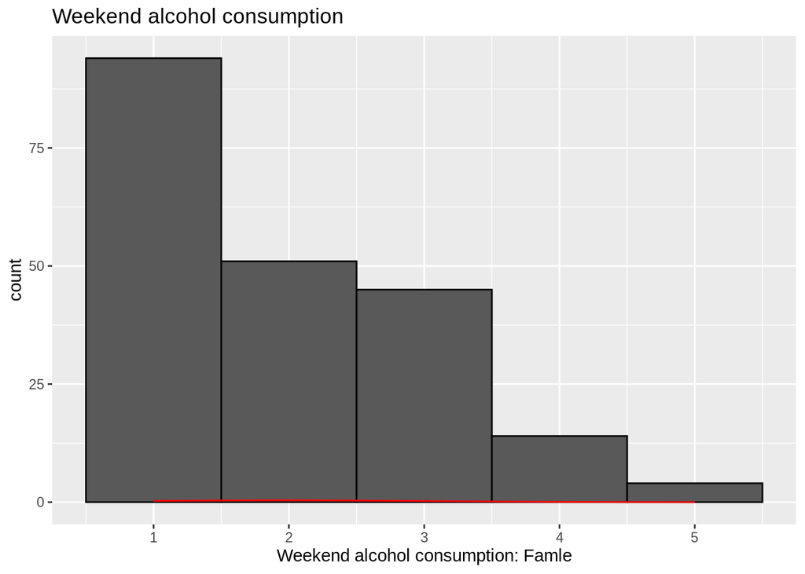

```r
ggplot(stdMath_F, aes(x=walc)) +
      ggtitle ("Weekend alcohol consumption")+
      labs(x="Weekend alcohol consumption: Famle") +
      geom_histogram(bins=5, colour="black") +
      scale_fill_gradient("Count", low="#DCDCDC", high="#7C7C7C") +
      stat_function(fun=dnorm, color="red",args=list(mean=mean(stdMath_F$walc,                                                       na.rm=TRUE),sd=sd(stdMath_F$walc, na.rm=TRUE)))
```

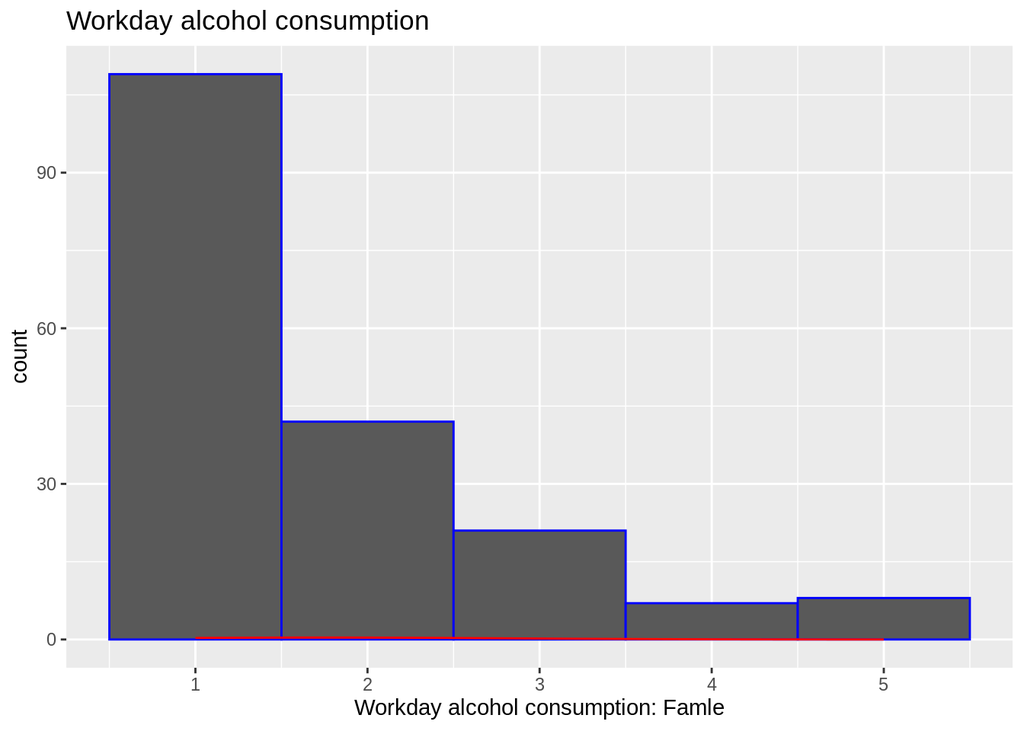

```r
# Weekend alcohol consumption
ggplot(stdMath_M, aes(x=dalc)) +
      ggtitle ("Workday alcohol consumption")+
      labs(x="Workday alcohol consumption: Famle") +
      geom_histogram(bins=5, colour="blue") +
      scale_fill_gradient("Count", low="#DCDCDC", high="#7C7C7C") +
      stat_function(fun=dnorm, color="red",args=list(mean=mean(stdMath_M$dalc,                                                       na.rm=TRUE),sd=sd(stdMath_M$dalc, na.rm=TRUE)))
```

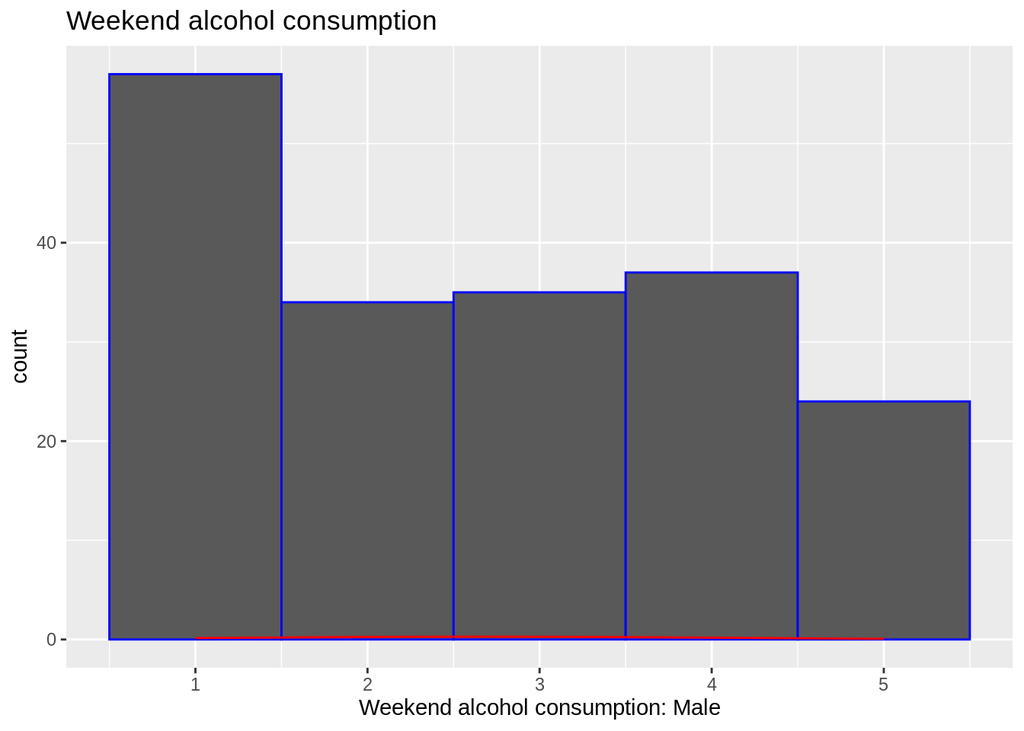

```r
ggplot(stdMath_M, aes(x=walc)) +
      ggtitle ("Weekend alcohol consumption")+
      labs(x="Weekend alcohol consumption: Male") +
      geom_histogram(bins=5, colour="blue") +
      scale_fill_gradient("Count", low="#DCDCDC", high="#7C7C7C") +
      stat_function(fun=dnorm, color="red",args=list(mean=mean(stdMath_M$walc,                                                       na.rm=TRUE),sd=sd(stdMath_M$walc, na.rm=TRUE)))
```

```r
# wilcoxon test syntax
# fmale group: Workday alcohol consumption and weekend alcohol consumption
stats::wilcox.test(stdMath_F$dalc, stdMath_F$walc, paired=TRUE)
```

```
##
##  Wilcoxon signed rank test with continuity correction
##
## data:  stdMath_F$dalc and stdMath_F$walc
## V = 79.5, p-value < 2.2e-16
## alternative hypothesis: true location shift is not equal to 0
```

```r
# wilcoxon test syntax
# male group: Workday alcohol consumption and weekend alcohol consumption
stats::wilcox.test(stdMath_M$dalc, stdMath_M$walc, paired=TRUE)
```

```
##
##  Wilcoxon signed rank test with continuity correction
##
## data:  stdMath_M$dalc and stdMath_M$walc
## V = 72, p-value < 2.2e-16
## alternative hypothesis: true location shift is not equal to 0
```

```r
coin::wilcox_test(dalc~as.factor(sex), data=stdMathData)
```

```
##
##  Asymptotic Wilcoxon-Mann-Whitney Test
##
## data:  dalc by as.factor(sex) (F, M)
## Z = -5.1552, p-value = 2.534e-07
## alternative hypothesis: true mu is not equal to 0
```

```r
coin::wilcox_test(walc~as.factor(sex), data=stdMathData)
```

```
##
##  Asymptotic Wilcoxon-Mann-Whitney Test
##
## data:  walc by as.factor(sex) (F, M)
## Z = -4.9506, p-value = 7.4e-07
## alternative hypothesis: true mu is not equal to 0
```

```r
wilcoeffsize1 = rstatix::wilcox_effsize(dalc ~ sex, data=stdMathData)
wilcoeffsize1
```

```
## # A tibble: 1 x 7
##   .y.   group1 group2 effsize    n1    n2 magnitude
## * <chr> <chr>  <chr>    <dbl> <int> <int> <ord>
## 1 dalc  F      M        0.259   208   187 small
```

```r
wilcoeffsize2 = rstatix::wilcox_effsize(walc ~ sex, data=stdMathData)
wilcoeffsize2
```

```
## # A tibble: 1 x 7
##   .y.   group1 group2 effsize    n1    n2 magnitude
## * <chr> <chr>  <chr>    <dbl> <int> <int> <ord>
## 1 walc  F      M        0.249   208   187 small
```

[output not shown]

### Non-Parametric test — sample for Portuguese language course

```r
# dalc and walc by sex repeat measure
# get subset data by sex
variableint <- c("sex", "dalc", "walc")
stdPorlag_F <- subset(stdPorlagData, sex=="F")[variableint]
stdPorlag_M <- subset(stdPorlagData, sex=="M")[variableint]

# wilcoxon test should both sub samples are the same length
# randomly choose the data in the female sub-samples
#set.seed(2000)
#stdMath_F <- sample_n(stdMath_F, nrow(stdMath_M))

summary(stdPorlag_F)
```

```
##      sex                 dalc            walc
##  Length:383         Min.   :1.000   Min.   :1.000
##  Class :character   1st Qu.:1.000   1st Qu.:1.000
##  Mode  :character   Median :1.000   Median :2.000
##                     Mean   :1.285   Mean   :1.937
##                     3rd Qu.:1.000   3rd Qu.:3.000
##                     Max.   :5.000   Max.   :5.000
```

```r
pastecs::stat.desc(stdPorlag_F, basic=F)
```

```
##          sex       dalc       walc
## median    NA 1.00000000 2.00000000
## mean      NA 1.28459530 1.93733681
## SE.mean   NA 0.03368183 0.05411808
## CI.mean   NA 0.06622499 0.10640661
## var       NA 0.43450029 1.12171750
## std.dev   NA 0.65916636 1.05911165
## coef.var  NA 0.51313154 0.54668432
```

```r
summary(stdPorlag_M)
```

```
##      sex                 dalc            walc
##  Length:266         Min.   :1.000   Min.   :1.000
##  Class :character   1st Qu.:1.000   1st Qu.:1.000
##  Mode  :character   Median :1.000   Median :3.000
##                     Mean   :1.816   Mean   :2.774
##                     3rd Qu.:2.000   3rd Qu.:4.000
##                     Max.   :5.000   Max.   :5.000
```

```r
pastecs::stat.desc(stdPorlag_M, basic=F)
```

```
##          sex       dalc       walc
## median    NA 1.00000000 3.00000000
## mean      NA 1.81578947 2.77443609
## SE.mean   NA 0.06985522 0.08674912
## CI.mean   NA 0.13754187 0.17080523
## var       NA 1.29801390 2.00175911
## std.dev   NA 1.13930413 1.41483537
## coef.var  NA 0.62744285 0.50995421
```

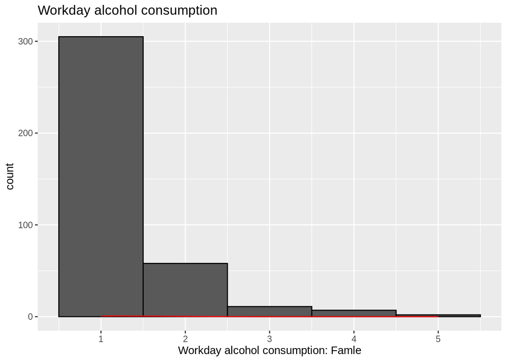

```r
# checking if the statistics dalc and walc are non parametric
# Workday alcohol consumption
ggplot(stdPorlag_F, aes(x=dalc)) +
      ggtitle ("Workday alcohol consumption")+
      labs(x="Workday alcohol consumption: Famle") +
      geom_histogram(bins=5, colour="black") +
      scale_fill_gradient("Count", low="#DCDCDC", high="#7C7C7C") +
      stat_function(fun=dnorm, color="red",args=list(mean=mean(stdMath_F$dalc,                                                       na.rm=TRUE),sd=sd(stdMath_F$dalc, na.rm=TRUE)))
```

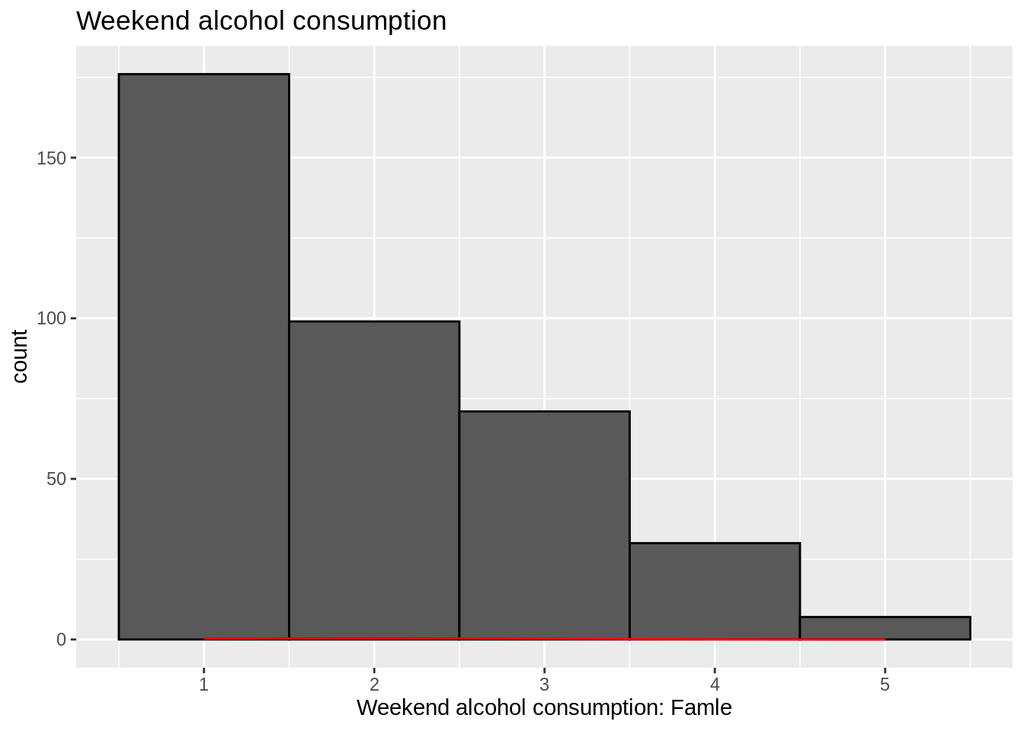

```r
ggplot(stdPorlag_F, aes(x=walc)) +
      ggtitle ("Weekend alcohol consumption")+
      labs(x="Weekend alcohol consumption: Famle") +
      geom_histogram(bins=5, colour="black") +
      scale_fill_gradient("Count", low="#DCDCDC", high="#7C7C7C") +
      stat_function(fun=dnorm, color="red",args=list(mean=mean(stdMath_F$walc,                                                       na.rm=TRUE),sd=sd(stdMath_F$walc, na.rm=TRUE)))
```

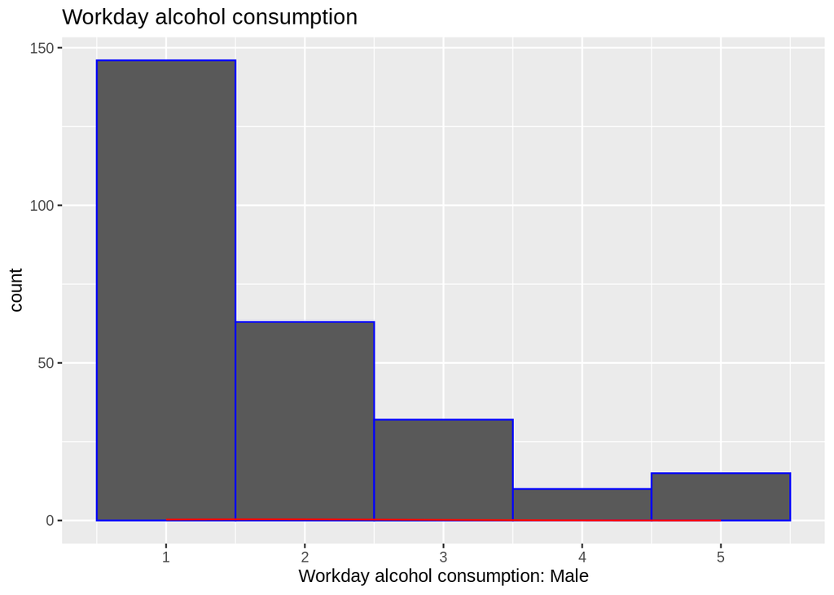

```r
# Weekend alcohol consumption
ggplot(stdPorlag_M, aes(x=dalc)) +
      ggtitle ("Workday alcohol consumption")+
      labs(x="Workday alcohol consumption: Male") +
      geom_histogram(bins=5, colour="blue") +
      scale_fill_gradient("Count", low="#DCDCDC", high="#7C7C7C") +
      stat_function(fun=dnorm, color="red",args=list(mean=mean(stdMath_M$dalc,                                                       na.rm=TRUE),sd=sd(stdMath_M$dalc, na.rm=TRUE)))
```

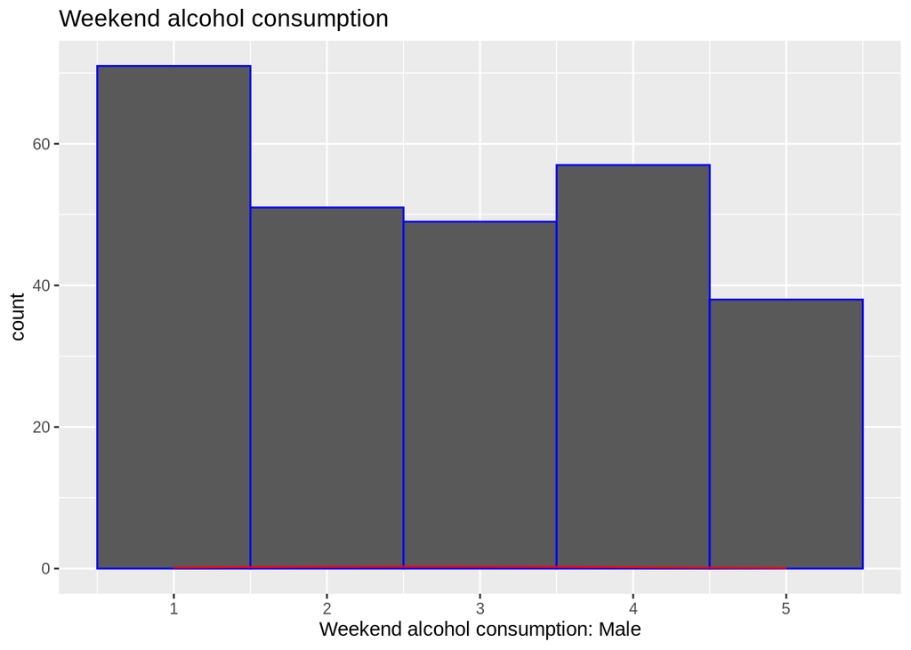

```r
ggplot(stdPorlag_M, aes(x=walc)) +
      ggtitle ("Weekend alcohol consumption")+
      labs(x="Weekend alcohol consumption: Male") +
      geom_histogram(bins=5, colour="blue") +
      scale_fill_gradient("Count", low="#DCDCDC", high="#7C7C7C") +
      stat_function(fun=dnorm, color="red",args=list(mean=mean(stdMath_M$walc,                                                       na.rm=TRUE),sd=sd(stdMath_M$walc, na.rm=TRUE)))
```

```r
# wilcoxon test syntax
# fmale group: Workday alcohol consumption and weekend alcohol consumption
stats::wilcox.test(stdPorlag_F$dalc, stdPorlag_F$walc, paired=TRUE)
```

```
##
##  Wilcoxon signed rank test with continuity correction
##
## data:  stdPorlag_F$dalc and stdPorlag_F$walc
## V = 884.5, p-value < 2.2e-16
## alternative hypothesis: true location shift is not equal to 0
```

```r
# male group: Workday alcohol consumption and weekend alcohol consumption
stats::wilcox.test(stdPorlag_M$dalc, stdPorlag_M$walc, paired=TRUE)
```

```
##
##  Wilcoxon signed rank test with continuity correction
##
## data:  stdPorlag_M$dalc and stdPorlag_M$walc
## V = 292, p-value < 2.2e-16
## alternative hypothesis: true location shift is not equal to 0
```

```r
stats::wilcox.test(stdPorlagData$dalc, stdPorlagData$walc, paired=TRUE)
```

```
##
##  Wilcoxon signed rank test with continuity correction
##
## data:  stdPorlagData$dalc and stdPorlagData$walc
## V = 2241.5, p-value < 2.2e-16
## alternative hypothesis: true location shift is not equal to 0
```

```r
coin::wilcox_test(dalc~as.factor(sex), data=stdPorlagData)
```

```
##
##  Asymptotic Wilcoxon-Mann-Whitney Test
##
## data:  dalc by as.factor(sex) (F, M)
## Z = -7.1733, p-value = 7.322e-13
## alternative hypothesis: true mu is not equal to 0
```

```r
coin::wilcox_test(walc~as.factor(sex), data=stdPorlagData)
```

```
##
##  Asymptotic Wilcoxon-Mann-Whitney Test
##
## data:  walc by as.factor(sex) (F, M)
## Z = -7.5404, p-value = 4.686e-14
## alternative hypothesis: true mu is not equal to 0
```

```r
wilcoeffsize1 = rstatix::wilcox_effsize(dalc ~ sex, data=stdPorlagData)
wilcoeffsize1
```

```
## # A tibble: 1 x 7
##   .y.   group1 group2 effsize    n1    n2 magnitude
## * <chr> <chr>  <chr>    <dbl> <int> <int> <ord>
## 1 dalc  F      M        0.282   383   266 small
```

```r
wilcoeffsize2 = rstatix::wilcox_effsize(walc ~ sex, data=stdPorlagData)
wilcoeffsize2
```

```
## # A tibble: 1 x 7
##   .y.   group1 group2 effsize    n1    n2 magnitude
## * <chr> <chr>  <chr>    <dbl> <int> <int> <ord>
## 1 walc  F      M        0.296   383   266 small
```

[output not shown]

#### Differences Nominal

for two independent variables in Math course. Sex - schoolup Questioin: “Is there a difference between boys and girls in terms of whether they have extra educational support?” H0: There is no difference HA: There is a difference

```r
#CrossTable(predictor, outcome, fisher = TRUE, chisq = TRUE, expected = TRUE)
gmodels::CrossTable(stdMathData$sex, stdMathData$schoolsup, fisher = TRUE, chisq = TRUE, expected = TRUE, sresid = TRUE, format = "SPSS")
```

```
##
##    Cell Contents
## |-------------------------|
## |                   Count |
## |         Expected Values |
## | Chi-square contribution |
## |             Row Percent |
## |          Column Percent |
## |           Total Percent |
## |            Std Residual |
## |-------------------------|
##
## Total Observations in Table:  395
##
##                 | stdMathData$schoolsup
## stdMathData$sex |       no  |      yes  | Row Total |
## ----------------|-----------|-----------|-----------|
##               F |      172  |       36  |      208  |
##                 |  181.144  |   26.856  |           |
##                 |    0.462  |    3.114  |           |
##                 |   82.692% |   17.308% |   52.658% |
##                 |   50.000% |   70.588% |           |
##                 |   43.544% |    9.114% |           |
##                 |   -0.679  |    1.765  |           |
## ----------------|-----------|-----------|-----------|
##               M |      172  |       15  |      187  |
##                 |  162.856  |   24.144  |           |
##                 |    0.513  |    3.463  |           |
##                 |   91.979% |    8.021% |   47.342% |
##                 |   50.000% |   29.412% |           |
##                 |   43.544% |    3.797% |           |
##                 |    0.717  |   -1.861  |           |
## ----------------|-----------|-----------|-----------|
##    Column Total |      344  |       51  |      395  |
##                 |   87.089% |   12.911% |           |
## ----------------|-----------|-----------|-----------|
##
##
## Statistics for All Table Factors
##
```

[output cut: 14 more lines]

```
## Alternative hypothesis: true odds ratio is not equal to 1
## p =  0.006658276
## 95% confidence interval:  0.204495 0.815756
##
## Alternative hypothesis: true odds ratio is less than 1
## p =  0.004275391
## 95% confidence interval:  0 0.740687
##
## Alternative hypothesis: true odds ratio is greater than 1
## p =  0.9983731
## 95% confidence interval:  0.2286257 Inf
##
##
##
##        Minimum expected frequency: 24.1443
```

```r
# simplistic way of doing Chi-Square

#Create your contingency table
contintable<-xtabs(~schoolsup+sex, data=stdMathData)

ctest<-stats::chisq.test(contintable, correct=TRUE)#chi square test
#correct=TRUE to get Yates correction needed for 2x2 table

ctest#will give you the details of the test statistic and p-value
```

```
##
##  Pearson's Chi-squared test with Yates' continuity correction
##
## data:  contintable
## X-squared = 6.7487, df = 1, p-value = 0.009382
```

```r
cat("\n ****************Expected frequencies:****************\n")
```

```
##
##  ****************Expected frequencies:****************
```

```r
ctest$expected#expected frequencies
```

```
##          sex
## schoolsup        F        M
##       no  181.1443 162.8557
##       yes  26.8557  24.1443
```

```r
cat("\n ****************Observed frequencies:****************\n")
```

```
##
##  ****************Observed frequencies:****************
```

```r
ctest$observed#observed frequencies
```

```
##          sex
## schoolsup   F   M
##       no  172 172
##       yes  36  15
```

```r
cat("\n *****p-value:Pearson's Chi-squared test with Yates' continuity correction *****\n")
```

```
##
##  *****p-value:Pearson's Chi-squared test with Yates' continuity correction *****
```

```r
ctest$p.value
```

```
## [1] 0.009381794
```

```r
#Calculate effect size
sjstats::phi(contintable)
```

```
## [1] 0.138271
```

```r
sjstats::cramer(contintable)
```

```
## [1] 0.138271
```

```
report Chi-Square Test for Independence

A Chi-Square test for independence (with Yates’ Continuity Correction) indicated significant association between gender and extra educational support, χ2(1,n=395)=6.75,p<0.05, phi=0.14).
```

## Difference for more than two groups

### Parametric

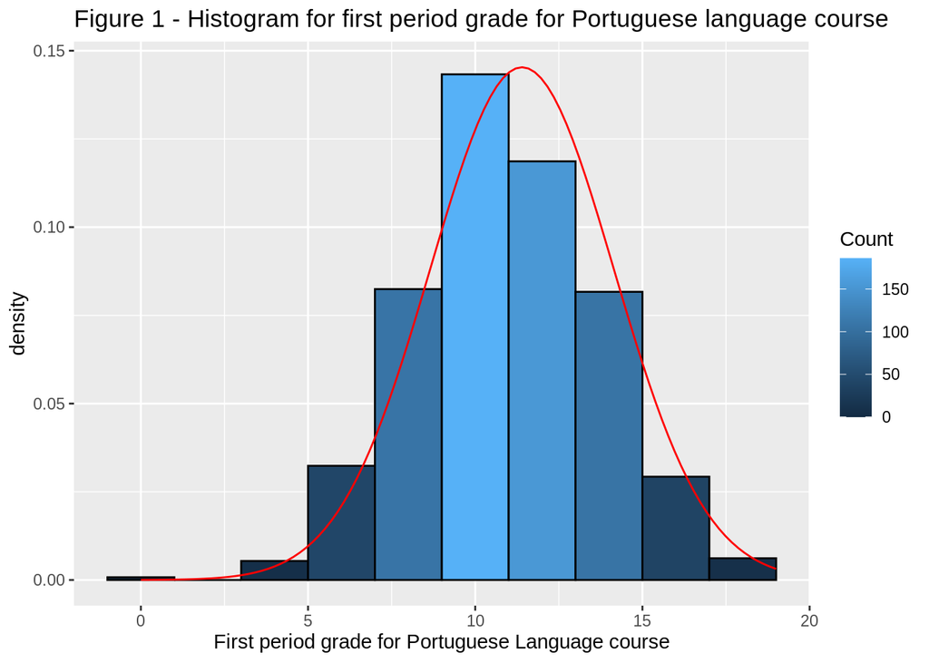

```r
# g3 Examine/Asses Normality

gg_g1 <- ggplot(stdPorlagData, aes(x=g1)) +
         ggtitle("Figure 1 - Histogram for first period grade for Portuguese language course") +
         labs(x="First period grade for Portuguese Language course") +

#manage binwidth and colours
          geom_histogram(binwidth=2, colour="black", aes(y=..density.., fill=..count..)) +
          scale_fill_gradient("Count") +

#adding a normal curve
#use stat_function to compute a normalized score for each value of g1
#pass the mean and standard deviation
#use the na.rm parameter to say how missing values are handled
         stat_function(fun=dnorm, color="red",args=list(mean=mean(stdPorlagData$g1, na.rm=TRUE), sd=sd(stdPorlagData$g1, na.rm=TRUE)))

#to display the graph request the contents of the variable be shown
gg_g1
```

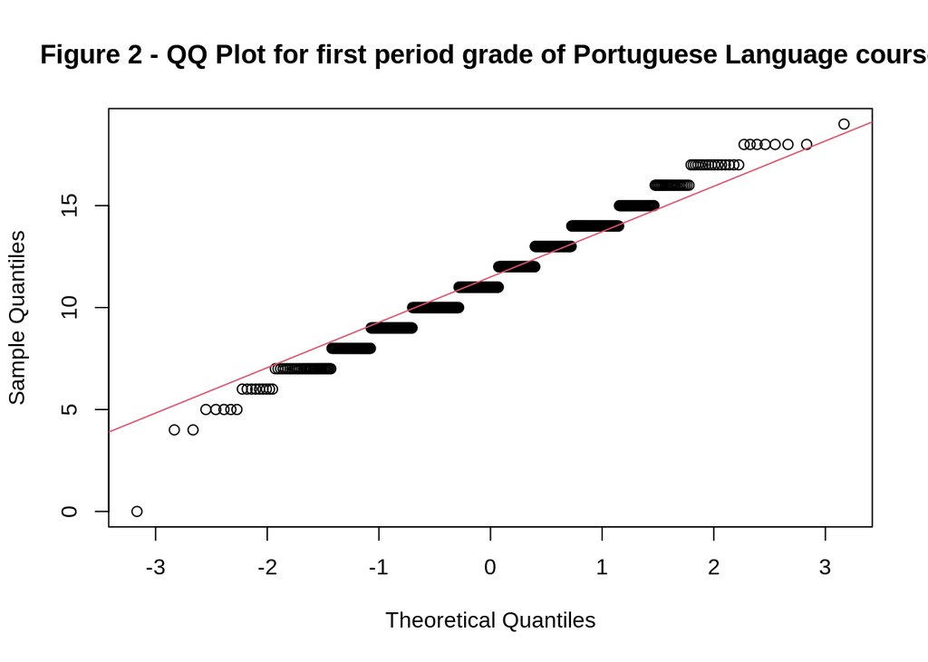

```r
qqnorm(stdPorlagData$g1, main = "Figure 2 - QQ Plot for first period grade of Portuguese Language course")
qqline(stdPorlagData$g1, col = 2) # show a trend line on the plot.
```

```r
#summary(stdPorlagData)
pastecs::stat.desc(stdPorlagData$g1, basic=F)
```

```
##       median         mean      SE.mean CI.mean.0.95          var      std.dev
##   11.0000000   11.3990755    0.1077611    0.2116031    7.5364806    2.7452651
##     coef.var
##    0.2408323
```

```r
tpskew <- semTools::skew(stdPorlagData$g1)
tpkurt <- semTools::kurtosis(stdPorlagData$g1)
#skew calculate
tpskew[1]/tpskew[2]
```

```
##   skew (g1)
## -0.02884671
```

```r
#kurtosis calculate
tpkurt[1]/tpkurt[2]
```

```
## Excess Kur (g2)
##       0.1905247
```

```r
# Calculate the percentage of standardized scores that are greated than 1.96
ztotsas <- abs(scale(stdPorlagData$g1))
FSA::perc(as.numeric(ztotsas), 1.96, "gt") # 'gt' = greater than 1.96, "leq" = equal, "lt"=less than
```

```
## [1] 6.317411
```

```r
FSA::perc(as.numeric(ztotsas), 3.29, "gt")
```

```
## [1] 0.1540832
```

[output not shown]

2. Differences more than 2 groups (ANOVA) Describle first peroid grades by group (studytime: group1, group 2, group 3, and group 4)

```r
#descriptive statistics by group
psych::describeBy(stdPorlagData$g1, stdPorlagData$studytime, mat=TRUE)
```

```
##     item group1 vars   n     mean       sd median  trimmed    mad min max range
## X11    1      1    1 212 10.50472 2.565719     10 10.44118 2.9652   4  18    14
## X12    2      2    1 305 11.53770 2.737301     12 11.55510 2.9652   0  18    18
## X13    3      3    1  97 12.42268 2.457281     13 12.44304 2.9652   7  19    12
## X14    4      4    1  35 12.77143 2.941445     13 12.72414 2.9652   5  18    13
##            skew    kurtosis        se
## X11  0.33306533  0.06113444 0.1762143
## X12 -0.23783505  0.33818097 0.1567374
## X13  0.02128150 -0.34868841 0.2494991
## X14 -0.03128245 -0.16105149 0.4971950
```

```r
#conduct Bartlett's test for homogeneity of variance in library car
stats::bartlett.test(g1 ~ studytime, data=stdPorlagData)
```

```
##
##  Bartlett test of homogeneity of variances
##
## data:  g1 by studytime
## Bartlett's K-squared = 2.9035, df = 3, p-value = 0.4067
```

```r
#p-value is > 0.05 so the result is not statistically significant so we can assume homogeneity
userfriendlyscience::oneway(as.factor(stdPorlagData$studytime), y=stdPorlagData$g1, posthoc="Tukey")
```

```
## ### Oneway Anova for y=g1 and x=studytime (groups: 1, 2, 3, 4)
##
## Omega squared: 95% CI = [.03; .11], point estimate = .07
## Eta Squared: 95% CI = [.04; .1], point estimate = .07
##
##                                      SS  Df     MS     F     p
## Between groups (error + effect)  342.99   3 114.33 16.24 <.001
## Within groups (error only)      4540.65 645   7.04
##
##
## ### Post hoc test: Tukey
##
##     diff lwr  upr  p adj
## 2-1 1.03 0.42 1.64 <.001
## 3-1 1.92 1.08 2.76 <.001
## 4-1 2.27 1.02 3.51 <.001
## 3-2 0.88 0.09 1.68 .023
## 4-2 1.23 0.01 2.45 .046
## 4-3 0.35 -1   1.7  .910
```

```r
# for reporting
res2<-stats::aov(g3 ~ studytime, data = stdPorlagData)
res2
```

```
## Call:
##    stats::aov(formula = g3 ~ studytime, data = stdPorlagData)
##
## Terms:
##                 studytime Residuals
## Sum of Squares    421.990  6341.277
## Deg. of Freedom         1       647
##
## Residual standard error: 3.130662
## Estimated effects may be unbalanced
```

```r
summary(res2) #get F statistic and p-value
```

```
##              Df Sum Sq Mean Sq F value   Pr(>F)
## studytime     1    422   422.0   43.06 1.09e-10 ***
## Residuals   647   6341     9.8
## ---
## Signif. codes:  0 '***' 0.001 '**' 0.01 '*' 0.05 '.' 0.1 ' ' 1
```

```r
#Get the F statistic into a variable
fstat<-summary(res2)[[1]][["F value"]][[1]]
fstat
```

```
## [1] 43.0556
```

```r
#Get the p value
aovpvalue<-summary(res2)[[1]][["Pr(>F)"]][[1]]
aovpvalue
```

```
## [1] 1.090809e-10
```

```r
#Calculate effect
aoveta<-sjstats::eta_sq(res2)[2]
aoveta
```

```
##   etasq
## 1 0.062
```

```r
#In the report we are using the res2 variable to retrieve the degrees of freedom
#and the eta_sq function from the sjstats package to calculate the effect
```

[output not shown]

### No Parametric

1. Kruskal-Wallis (Non-Parametric)
2. Friedmans ANOVA (non-parametric) for repeated measures

#### Kruska-wallis test

Nominal — Guardian (student’s guardian (mother, father or other)) Ordinal — health (current health status (from 1 - very bad to 5 - very good)) group by guardian (3 groups)

```r
psych::describeBy(as.numeric(stdPorlagData$health), factor(stdPorlagData$guardian),mat=TRUE)
```

```
##     item group1 vars   n     mean       sd median  trimmed    mad min max range
## X11    1 father    1 153 3.496732 1.419434      4 3.617886 1.4826   1   5     4
## X12    2 mother    1 455 3.545055 1.460814      4 3.679452 1.4826   1   5     4
## X13    3  other    1  41 3.585366 1.413782      4 3.696970 1.4826   1   5     4
##           skew  kurtosis         se
## X11 -0.3636596 -1.252315 0.11475441
## X12 -0.5498250 -1.080518 0.06848404
## X13 -0.3506474 -1.413085 0.22079571
```

```r
#run a kruskal wallis test
stats::kruskal.test(health~guardian,data=stdPorlagData)
```

```
##
##  Kruskal-Wallis rank sum test
##
## data:  health by guardian
## Kruskal-Wallis chi-squared = 0.233, df = 2, p-value = 0.89
```

```r
#post-hot test for between groups
tmp_bonferroni<-FSA::dunnTest(x=as.numeric(stdPorlagData$health), g=factor(stdPorlagData$guardian), method="bonferroni")
print(tmp_bonferroni, dunn.test.results = TRUE)
```

```
##   Kruskal-Wallis rank sum test
##
##  data: x and g
##  Kruskal-Wallis chi-squared = 0.233, df = 2, p-value = 0.89
##
##
##                               Comparison of x by g
##                                   (Bonferroni)
##  Col Mean-|
##  Row Mean |     father     mother
##  ---------+----------------------
##    mother |  -0.428831
##           |     1.0000
##     other |  -0.373867  -0.157437
##           |     1.0000     1.0000
##
##  alpha = 0.05
##  Reject Ho if p <= alpha
```

```r
# bootstrapping effect size
rstatix::kruskal_effsize(stdPorlagData, health~guardian, ci = FALSE, conf.level = 0.95, ci.type = "perc", nboot = 1000)
```

```
## # A tibble: 1 x 5
##   .y.        n  effsize method  magnitude
## * <chr>  <int>    <dbl> <chr>   <ord>
## 1 health   649 -0.00274 eta2[H] small
```

[output not shown]

G1 G2 G3 for each students ranks

```r
Responses <- na.omit(with(stdPorlagData, cbind(g1, g2, g3)))
cat("\nMedians:\n")
```

```
##
## Medians:
```

```r
#print out the medians of each of our variables
print(apply(Responses, 2, median))
```

```
## g1 g2 g3
## 11 11 12
```

```r
stats::friedman.test(Responses)
```

```
##
##  Friedman rank sum test
##
## data:  Responses
## Friedman chi-squared = 167.33, df = 2, p-value < 2.2e-16
```

[output not shown]